# Глубокое обучение с использованием языка R и библиотеки mxnet. Часть 1. Основы

```r
setwd("~/R/mxnet_manual")
library(mxnet)
```

Привет, Хабр! Эта статья является первой частью руководства по приготовления нейронных сетей с использованием библиотеки **mxnet** на языке R. За основу взята книга [Deep Learning - The Straight Dope](https://github.com/zackchase/mxnet-the-straight-dope), объема которой достаточно для осознанного использования **mxnet** на Питоне. Примеры оттуда будут воспроизводиться с поправкой на отсутствие реализации интерфейса Gluon для R. В первой части рассмотрим общие принципы работы и реализуем простую линейную модель для решения задачи регрессии.

## Используемый набор данных

Создадим искусственный набор данных из 10000 наблюдений (`num_examples`) с двумя признаками (`num_inputs`) и одной целевой переменной (`num_outputs`). Истинная форма зависимости между предикторами и целевой переменной задана функцией `real_fn()`, к сгенерированных при помощи этой функции значениям добавлен небольшой гауссовский шум `0.01 * rnorm(num_examples)`:

```r
num_inputs <- 2
num_outputs <- 1
num_examples <- 10000

real_fn <- function(x) {
  2 * x[, 1] - 3.4 * x[, 2] + 4.2
}

X <- matrix(rnorm(num_examples * num_inputs),
            ncol = num_inputs)

noise <- 0.01 * rnorm(num_examples)

y <- real_fn(X) + noise
```

## Основная функция для обучения нейросетей

За обучение нейросетей прямого распространения отвечает функция `mx.model.FeedForward.create()`. Список принимаемых ею параметров выглядит следующим образом:

- `symbol` - архитектура сети в виде символьного описания. Это не совсем граф вычислений, поскольку в нем не заданы размерности тензоров и функция потерь, но что-то похожее. Архитектуру можно нарисовать при помощи функции `graph.viz()`, пример будет ниже;
- `X` - матрица/массив или итератор данных, используемых для обучения. Массивы используем, когда данные целиком помещаются в память, а итераторы - когда не помещаются. Есть несколько готовых итераторов (по массивам, по картинкам в бинарном формате RecordIO, по csv-файлам) и возможность создавать свои собственные;
- `y` - значения целевой переменной. Задается только в случае, когда `X` является массивом, в противном случае итератор должен возвращать все необходимое для обучения;
- `ctx` - устройство или список устройств, используемых для обучения. Объект класса MXContext, создаваемый при помощи `mx.cpu()` или `mx.gpu()`;
- `begin.round` - начальное значение счетчика итераций (эпох) обучения. Менять значение по умолчанию (1) нужно только при дообучении модели;
- `num.round` - количество эпох;
- `optimizer` - используемый оптимизатор, заданный по имени (в виде строки). По умолчанию - стохастический градиентный спуск (“sgd”). Пример настройки параметров оптимизатора представлен ниже;
- `initializer` - объект, задающий схему инициализации параметров модели;
- `eval.data` - список вида `list(data = R.array, label = R.array)` или итератор с валидационными данными;
- `eval.metric` - функция для оценка качества модели. Помимо доступных вариантов можно также использовать собственноручно написанную;
- `epoch.end.callback` - функция, запускаемая после каждой эпохи обучения;
- `batch.end.callback` - функция, запускаемая после каждого мини-батча;
- `array.batch.size` - размер мини-батча при использовании данных в виде массива. При использовании итераторов размер мини-батча в них же и задается;
- `array.layout` - “auto”, “colmajor” или “rowmajor” (по умолчанию - “auto”). Формат массивов: для матрицы “rowmajor” означает, что `dim(X) = c(nexample, nfeatures)`, а “colmajor” - что `dim(X) = c(nfeatures, nexample)`. Формат “rowmajor” допустим только для матриц. Функция `mx.io.arrayiter()` в явном виде потребует преобразовать данные к формату “colmajor”, т.е. матрица будет транспонированной по отношению к привычному виду с наблюдениями в строках и признаками в столбцах;
- `kvstore` - задается в виде строки и отвечает за схему синхронизации при обучении на нескольких устройства. По умолчанию равен “local”;
- `verbose` - отвечает за вывод информационных сообщений в процессе обучения. По умолчанию равен TRUE;
- `arg.params` - опциональный параметр со списком массивов NDArray, содержащих веса модели;
- `aux.params` - аналогичный список дополнительных параметров;
- `input.names` - имена символов, подаваемых на вход;
- `output.names` - имена символов, получаемых на выходе;
- `fixed.param` - параметры, которые остаются фиксированными в ходе обучения (не обучаются);
- `allow.extra.params` - разрешает передавать дополнительные параметры, которые не требуются согласно символьному описанию модели. Если задать равным TRUE, при наличии таких лишних параметров в списках `arg.params` и `aux.params` ошибка появляться не будет.

## Итераторы

Создадим итератор по массиву (матрице) данных:

```r
batch_size <- 4

train_data <- mx.io.arrayiter(t(X),
                              y,
                              batch.size = batch_size,
                              shuffle = TRUE)
```

Функция принимает на вход массив или матрицу признаков (в данном случае, как уже было сказано, матрицу нужно транспонировать), массив со значениями целевой переменной и размер мини-батча. Также мы включили перемешивание наблюдений опцией `shuffl e= TRUE`. Список всех доступных итераторов выглядит так:

```r
apropos("mx.io")

 # [1] "mx.io.arrayiter"               "mx.io.bucket.iter"
 # [3] "mx.io.CSVIter"                 "mx.io.extract"
 # [5] "mx.io.ImageDetRecordIter"      "mx.io.ImageRecordIter"
 # [7] "mx.io.ImageRecordIter_v1"      "mx.io.ImageRecordUInt8Iter"
 # [9] "mx.io.ImageRecordUInt8Iter_v1" "mx.io.LibSVMIter"
```

Но сейчас мы не будем рассматривать ни остальные варианты, ни написание собственных итераторов.

## Архитектура сети

Архитектура сети описывается путем последовательных вызовов функций семейства `mx.symbol.*`, каждая из которых добавляет к модели абстрактные представления слоев: полносвязного, сверточного, пулингового и других. Слоев доступно очень много:

```r
apropos("mx.symbol")

#   [1] "is.mx.symbol"
#   [2] "mx.symbol.abs"
#   [3] "mx.symbol.Activation"
#   [4] "mx.symbol.adam_update"
#   [5] "mx.symbol.add_n"
# .....
# [208] "mx.symbol.transpose"
# [209] "mx.symbol.trunc"
# [210] "mx.symbol.uniform"
# [211] "mx.symbol.UpSampling"
# [212] "mx.symbol.Variable"
# [213] "mx.symbol.where"
# [214] "mx.symbol.zeros_like"
```

Для создания простой линейной модели, решающей задачу регрессии, служит следующий код:

```r
data <- mx.symbol.Variable("data")
fc1 <- mx.symbol.FullyConnected(data,
                                num_hidden = 1)
linreg <- mx.symbol.LinearRegressionOutput(fc1)
```

Нарисуем получившуюся архитектуру:

```r
graph.viz(linreg)
```

[interactive chart not shown]

## Инициализатор

Инициализатор определяет, с каких начальных значений стартует обучение нейросети. Поскольку наша сеть очень простая и неглубокая, достаточно инициализировать веса случайными значениями, имеющими нормальное распределение:

```r
initializer <- mx.init.normal(sd = 0.1)
```

Единственным принимаемым параметров в данном случае является стандартное отклонение.

Для глубоких сетей правильная инициализация весов имеет большое значение, поэтому мы бы воспользовались вариантом `mx.init.Xavier()`.

## Оптимизатор

Оптимизатор определяет способ обновления весов сети. Доступные варианты: sgd, rmsprop, adam, adagrad и adadelta. Создать оптимизатор с нужными настройками можно при помощи общей функции `mx.opt.create()`:

```r
optimizer <- mx.opt.create("sgd",
                           learning.rate = 2e-5,
                           momentum = 0.9)
```

Чтобы узнать о параметрах каждого из оптимизаторов, нужно воспользоваться справкой:

```r
?mx.opt.sgd
?mx.opt.rmsprop
?mx.opt.adam
?mx.opt.adagrad
?mx.opt.adadelta
```

Сами эти функции привычным способом вызвать нельзя (но к ним можно получить доступ: `mxnet:::mx.opt.adagrad`).

## Функции обратного вызова (колбэки)

Сохраним историю обучения при помощи соответствующей callback-функции:

```r
logger <- mx.metric.logger()
epoch.end.callback <- mx.callback.log.train.metric(
    period = 1,
    logger = logger)
```

После обучения объект `logger` будет содержать информацию вида

```r
logger$train
# [1] 2.322148818 0.318418684 0.044898842 0.011428233 0.009461375
```

## Обучение модели

```r
model <- mx.model.FeedForward.create(
    symbol = linreg,
    X = train_data,
    ctx = mx.cpu(),
    num.round = 5,
    initializer = initializer,
    optimizer = optimizer,
    eval.metric = mx.metric.rmse,
    epoch.end.callback = epoch.end.callback)
```

```
## Start training with 1 devices
```

```
## [1] Train-rmse=2.37154568856728
```

```
## [2] Train-rmse=0.312268855850183
```

```
## [3] Train-rmse=0.042428765425302
```

```
## [4] Train-rmse=0.0110728631018276
```

```
## [5] Train-rmse=0.00937463980492928
```

Изобразим историю обучения:

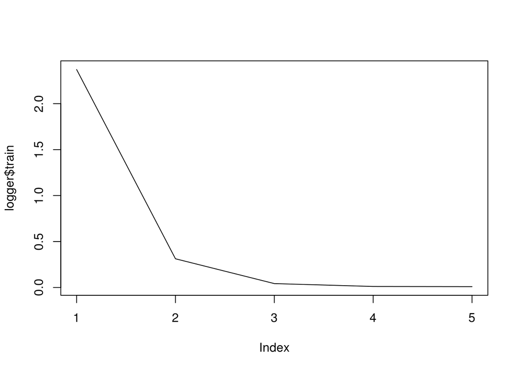

```r
plot(logger$train, type = "l")
```

Проверим, как работает наша модель:

```r
predict(model, t(X[1:5, ]))
```

```
##            [,1]     [,2]      [,3]     [,4]       [,5]
## [1,] -0.9477115 12.27576 0.1180005 7.420683 -0.8382998
```

```r
y[1:5]
```

```
## [1] -0.9493222 12.2803599  0.1136631  7.4230513 -0.8376811
```

В следующем сообщении мы перейдем к более жизненным примерам и решим задачу классификации на реальных данных.